# Customer Insights – A Statistical Investigation

## Objective

This project analyzes customer demographics, spending behavior, engagement patterns, and demographic influences using statistical methods.

### Business Goals

- Understand customer demographics
- Analyze spending behavior
- Identify customer segments
- Perform hypothesis testing
- Generate business insights

Dataset: US_Customer_Insights_Dataset.csv

```python
import pandas as pd
import numpy as np

import matplotlib.pyplot as plt
import seaborn as sns

from scipy import stats
from scipy.stats import ttest_ind, f_oneway, chi2_contingency, pearsonr

import warnings
warnings.filterwarnings("ignore")

plt.style.use('ggplot')
```

# Step 1: Load and Understand the Data

In this step we:

- Load the dataset
- View first few records
- Check data types
- Check missing values
- Identify numerical and categorical variables

```python
df = pd.read_csv("US_Customer_Insights_Dataset.csv")

print("Shape of Dataset:", df.shape)

df.head()
```

```
Shape of Dataset: (10675, 12)
```

|  | CustomerID | Name | State | Education | Gender | Age | Married | NumPets | JoinDate | TransactionDate | MonthlySpend | DaysSinceLastInteraction |
| --- | --- | --- | --- | --- | --- | --- | --- | --- | --- | --- | --- | --- |
| 0 | CUST10319 | Scott Perez | Florida | High School | Non-Binary | 47 | Yes | 1 | 9/19/21 | 9/2/24 | 1281.74 | 332 |
| 1 | CUST10695 | Jennifer Burton | Washington | Master | Male | 72 | Yes | 0 | 4/5/24 | 6/2/24 | 429.46 | 424 |
| 2 | CUST10297 | Michelle Rogers | Arizona | Master | Female | 40 | Yes | 2 | 7/24/24 | 2/28/25 | 510.34 | 153 |
| 3 | CUST10103 | Brooke Hendricks | Texas | Master | Male | 27 | Yes | 0 | 8/12/23 | 3/29/25 | 396.47 | 124 |
| 4 | CUST10219 | Karen Johns | Texas | High School | Female | 28 | Yes | 1 | 12/6/21 | 7/24/22 | 139.68 | 1103 |

```python
df.info()
```

```
<class 'pandas.core.frame.DataFrame'>
RangeIndex: 10675 entries, 0 to 10674
Data columns (total 12 columns):
 #   Column                    Non-Null Count  Dtype
---  ------                    --------------  -----
 0   CustomerID                10675 non-null  object
 1   Name                      10675 non-null  object
 2   State                     10675 non-null  object
 3   Education                 10675 non-null  object
 4   Gender                    10675 non-null  object
 5   Age                       10675 non-null  int64
 6   Married                   10675 non-null  object
 7   NumPets                   10675 non-null  int64
 8   JoinDate                  10675 non-null  object
 9   TransactionDate           10675 non-null  object
 10  MonthlySpend              10675 non-null  float64
 11  DaysSinceLastInteraction  10675 non-null  int64
dtypes: float64(1), int64(3), object(8)
memory usage: 1000.9+ KB
```

```python
df.isnull().sum()
```

```
CustomerID                  0
Name                        0
State                       0
Education                   0
Gender                      0
Age                         0
Married                     0
NumPets                     0
JoinDate                    0
TransactionDate             0
MonthlySpend                0
DaysSinceLastInteraction    0
dtype: int64
```

```python
df.describe()
```

|  | Age | NumPets | MonthlySpend | DaysSinceLastInteraction |
| --- | --- | --- | --- | --- |
| count | 10675.000000 | 10675.000000 | 10675.000000 | 10675.000000 |
| mean | 49.474567 | 1.340515 | 331.610315 | 538.469883 |
| std | 18.221365 | 1.150849 | 225.799253 | 398.766747 |
| min | 18.000000 | 0.000000 | 3.890000 | 1.000000 |
| 25% | 35.000000 | 0.000000 | 165.495000 | 218.000000 |
| 50% | 49.000000 | 1.000000 | 282.110000 | 445.000000 |
| 75% | 66.000000 | 2.000000 | 443.255000 | 788.500000 |
| max | 80.000000 | 4.000000 | 1740.420000 | 1791.000000 |

```python
numerical_cols = df.select_dtypes(include=np.number).columns
categorical_cols = df.select_dtypes(include='object').columns

print("Numerical Columns:")
print(list(numerical_cols))

print("\nCategorical Columns:")
print(list(categorical_cols))
```

```
Numerical Columns:
['Age', 'NumPets', 'MonthlySpend', 'DaysSinceLastInteraction']

Categorical Columns:
['CustomerID', 'Name', 'State', 'Education', 'Gender', 'Married', 'JoinDate', 'TransactionDate']
```

# Step 2: Descriptive Statistics

We calculate:

### Numerical Variables

- Mean
- Median
- Standard Deviation

### Categorical Variables

- Mode

```python
stats_df = pd.DataFrame({
    "Mean": df[['Age','MonthlySpend','DaysSinceLastInteraction']].mean(),
    "Median": df[['Age','MonthlySpend','DaysSinceLastInteraction']].median(),
    "Std Dev": df[['Age','MonthlySpend','DaysSinceLastInteraction']].std()
})

stats_df
```

|  | Mean | Median | Std Dev |
| --- | --- | --- | --- |
| Age | 49.474567 | 49.00 | 18.221365 |
| MonthlySpend | 331.610315 | 282.11 | 225.799253 |
| DaysSinceLastInteraction | 538.469883 | 445.00 | 398.766747 |

### Statistical Summary Insights

The table highlights key descriptive statistics for customer attributes:

** Analyst Takeaway:**

- Spending distribution is skewed — focus on identifying and nurturing high-value customers.
- Engagement gaps are significant — reactivation campaigns could reduce churn.
- Age diversity supports tailored marketing strategies across segments.

```python
print("Gender Mode:")
print(df['Gender'].mode()[0])

print("\nEducation Mode:")
print(df['Education'].mode()[0])

print("\nMarried Mode:")
print(df['Married'].mode()[0])
```

```
Gender Mode:
Male

Education Mode:
Master

Married Mode:
No
```

# Step 3: Data Visualization

Visualizations help identify:

- Distribution
- Outliers
- Trends
- Relationships

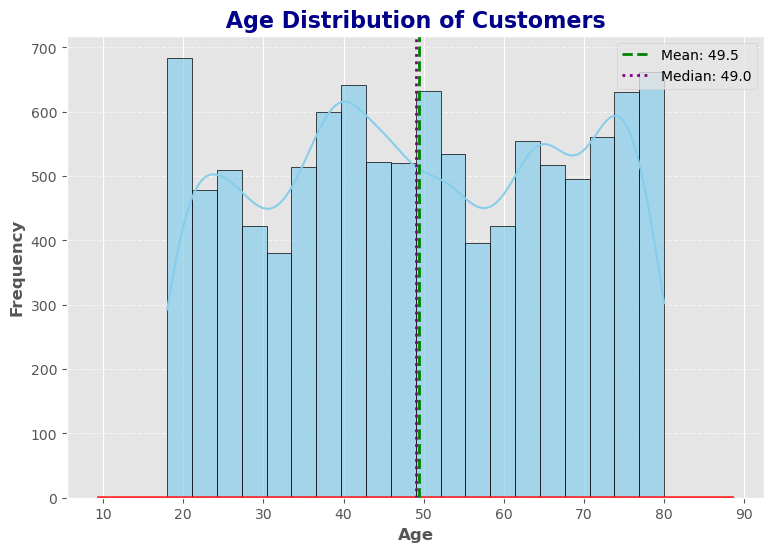

```python
plt.figure(figsize=(9,6))

# Histogram with custom colors and transparency
sns.histplot(df['Age'], bins=20, kde=True,
             color="skyblue", edgecolor="black", alpha=0.7)

# Overlay KDE with bold contrasting color
sns.kdeplot(df['Age'], color="red", linewidth=2)

# Titles and labels with styling
plt.title(" Age Distribution of Customers ", fontsize=16, fontweight="bold", color="darkblue")
plt.xlabel("Age", fontsize=12, fontweight="bold")
plt.ylabel("Frequency", fontsize=12, fontweight="bold")

# Add gridlines for readability
plt.grid(axis="y", linestyle="--", alpha=0.6)

# Highlight mean with vertical line
plt.axvline(df['Age'].mean(), color="green", linestyle="--", linewidth=2, label=f"Mean: {df['Age'].mean():.1f}")

# Highlight median with vertical line
plt.axvline(df['Age'].median(), color="purple", linestyle=":", linewidth=2, label=f"Median: {df['Age'].median():.1f}")

# Add legend
plt.legend()

plt.show()
```

### Age Distribution Insights

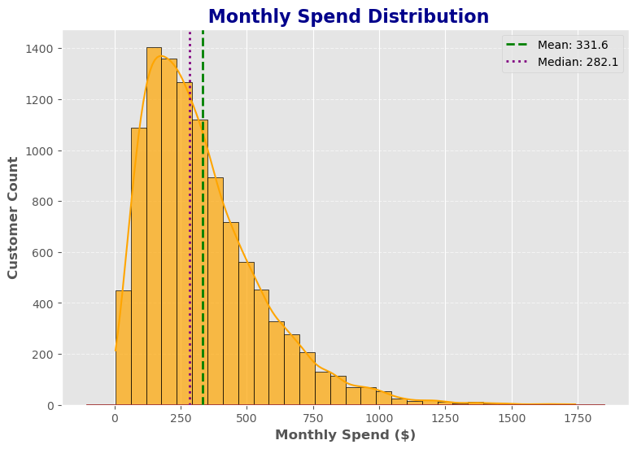

```python
# monthly spend distribution
plt.figure(figsize=(9,6))

# Histogram with custom styling
sns.histplot(df['MonthlySpend'], bins=30, kde=True,
             color="orange", edgecolor="black", alpha=0.7)

# Overlay KDE with bold contrasting color
sns.kdeplot(df['MonthlySpend'], color="darkred", linewidth=2)

# Titles and labels with styling
plt.title(" Monthly Spend Distribution", fontsize=16, fontweight="bold", color="darkblue")
plt.xlabel("Monthly Spend ($)", fontsize=12, fontweight="bold")
plt.ylabel("Customer Count", fontsize=12, fontweight="bold")

# Add gridlines for readability
plt.grid(axis="y", linestyle="--", alpha=0.6)

# Highlight mean with vertical line
plt.axvline(df['MonthlySpend'].mean(), color="green", linestyle="--", linewidth=2,
            label=f"Mean: {df['MonthlySpend'].mean():.1f}")

# Highlight median with vertical line
plt.axvline(df['MonthlySpend'].median(), color="purple", linestyle=":", linewidth=2,
            label=f"Median: {df['MonthlySpend'].median():.1f}")

# Add legend
plt.legend()

plt.show()
```

### Monthly Spend Distribution Insights

The histogram reveals how customers differ in their monthly spending:

**Analyst Takeaway:**  
Customer spending is uneven, with a strong base of moderate spenders and a small but impactful premium group. Strategies should balance retention of the majority while investing in personalized engagement for high-value customers.

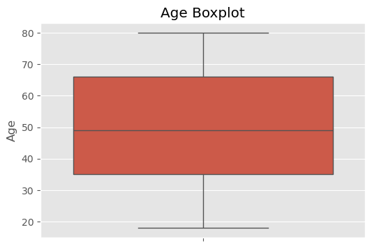

```python
# Age Distribution — Boxplot
plt.figure(figsize=(6,4))
sns.boxplot(y=df['Age'])

plt.title("Age Boxplot")
plt.show()
```

### Age Distribution — Boxplot Analysis

The boxplot provides a clear summary of the **Age** variable:

- **Median Age (~50 years):** The central line indicates that half of the population is younger than 50, while the other half is older.
- **Interquartile Range (IQR ~35–65 years):** Most individuals fall within this middle spread, showing the typical age range of the dataset.
- **Whiskers (~18–80 years):** These extend to the minimum and maximum non-outlier values, highlighting the broader age span.
- **Outliers:** Any points beyond the whiskers suggest unusually young or old individuals compared to the majority.

**Business Insight:**  
The age distribution is fairly balanced around middle age, with a wide spread across younger and older groups. This indicates potential for **segmentation strategies**—for example, tailoring products or services differently for younger (<35), middle-aged (35–65), and senior (>65) customers.

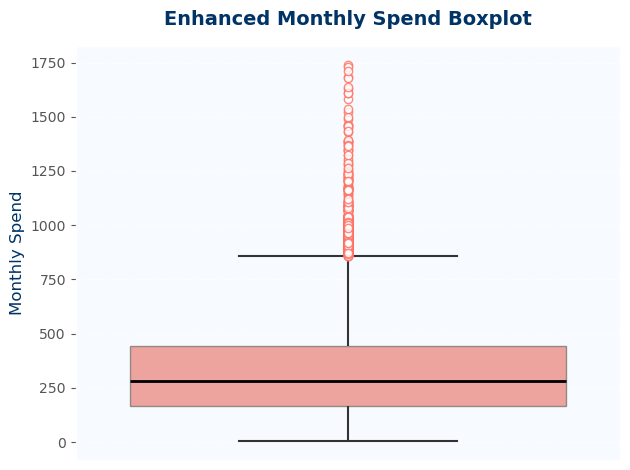

```python
# Monthly Spend Boxplot
sns.boxplot(
    y=df['MonthlySpend'],
    color="#FF6F61",           # elegant coral tone
    boxprops=dict(alpha=0.7),
    medianprops=dict(color="black", linewidth=2),
    whiskerprops=dict(color="#333", linewidth=1.5),
    capprops=dict(color="#333", linewidth=1.5),
    flierprops=dict(marker='o', markerfacecolor='white', markeredgecolor='#FF6F61', alpha=0.8)
)

# Add title and labels with styling
plt.title("Enhanced Monthly Spend Boxplot", fontsize=14, fontweight='bold', color="#003366", pad=15)
plt.ylabel("Monthly Spend", fontsize=12, color="#003366")
plt.xticks([])
plt.grid(axis='y', linestyle='--', alpha=0.6)

# Optional background polish
plt.gca().set_facecolor("#F7FBFF")
plt.tight_layout()
plt.show()
```

### Monthly Spend — Boxplot Insight

The boxplot provides a clear overview of customer spending behavior:

- **Median Spend (~300):** Indicates that half of the customers spend below USD 300 monthly, while the other half spend more.
- **IQR (Interquartile Range <500):** Most customers fall within this range, showing a concentrated spending pattern among the majority.
- **Outliers (up to ~1750):** A few customers spend significantly higher amounts, representing premium or high-value segments.
- **Distribution Shape:** The presence of multiple outliers and a long upper whisker suggests a **right-skewed distribution**, meaning a small group drives higher revenue.

**Analytical Insight:**  
The spending pattern reveals that while most customers are moderate spenders, a small elite group contributes disproportionately to total revenue. This insight can guide **customer segmentation** and **targeted marketing strategies**—for instance, designing loyalty programs for high spenders and affordability campaigns for the majority.

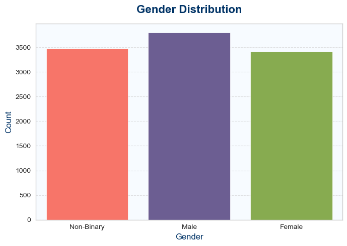

```python
# Gender Distribution Plot
# Set a modern theme
sns.set_style("whitegrid")
plt.figure(figsize=(7,5))

# Custom color palette
palette = ["#FF6F61", "#6B5B95", "#88B04B"]  # Coral, Purple, Green

# Create countplot with enhancements
sns.countplot(
    data=df,
    x='Gender',
    palette=palette,
    saturation=0.9
)

# Add title and labels with styling
plt.title("Gender Distribution", fontsize=16, fontweight='bold', color="#003366", pad=15)
plt.xlabel("Gender", fontsize=12, color="#003366")
plt.ylabel("Count", fontsize=12, color="#003366")

# Add gridlines for readability
plt.grid(axis='y', linestyle='--', alpha=0.6)

# Optional background polish
plt.gca().set_facecolor("#F7FBFF")

# Show plot
plt.tight_layout()
plt.show()
```

### Gender Distribution — Analytical Insight

The bar chart highlights the composition of customers across gender categories:

**Key Observations:**

- The dataset shows a **balanced distribution** across genders, with no single group overwhelmingly dominant.
- The presence of a substantial **non-binary segment** indicates inclusivity and diversity in the customer base.
- Differences between categories are relatively small, suggesting that **gender-based segmentation alone may not be a strong differentiator**.

**Business Insight:**  
Marketing and engagement strategies should remain **inclusive and diversified**, ensuring equal representation across all gender identities. Since the distribution is balanced, campaigns can focus more on **behavioral or spending patterns** rather than relying solely on gender segmentation.

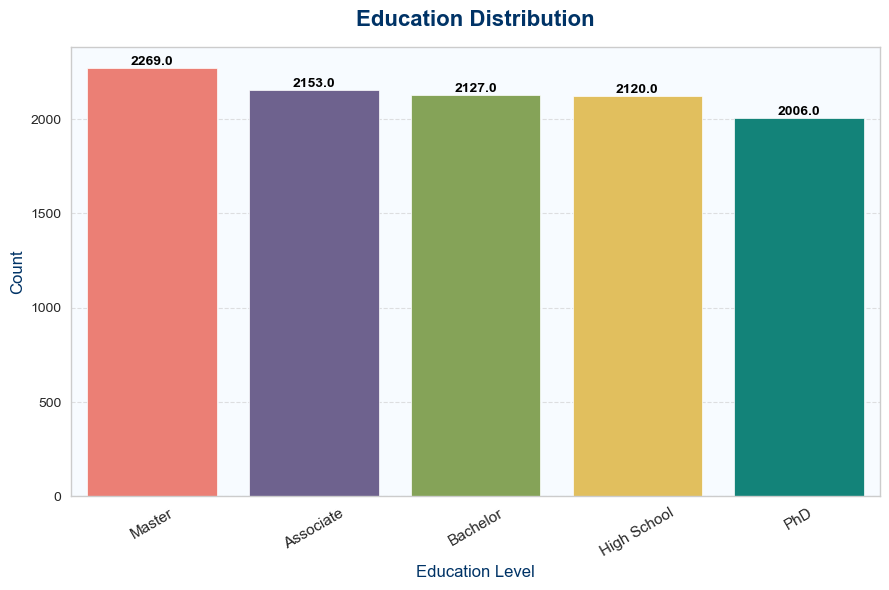

```
Education Distribution (%):
Education
Master         21.26
Associate      20.17
Bachelor       19.93
High School    19.86
PhD            18.79
Name: proportion, dtype: float64
```

```python
# Education Distribution Plot
# Set modern style
sns.set_style("whitegrid")
plt.figure(figsize=(9,6))

# Custom palette for categories
palette = ["#FF6F61", "#6B5B95", "#88B04B", "#F7C948", "#009688"]

# Create countplot
ax = sns.countplot(
    data=df,
    x='Education',
    palette=palette,
    order=df['Education'].value_counts().index  # sort by frequency
)

# Rotate x labels for clarity
plt.xticks(rotation=30, fontsize=11)
plt.title("Education Distribution", fontsize=16, fontweight='bold', color="#003366", pad=15)
plt.xlabel("Education Level", fontsize=12, color="#003366")
plt.ylabel("Count", fontsize=12, color="#003366")

# Add value labels on top of bars
for p in ax.patches:
    ax.annotate(
        f"{p.get_height()}",
        (p.get_x() + p.get_width() / 2., p.get_height()),
        ha='center', va='bottom',
        fontsize=10, color="black", fontweight="bold"
    )

# Optional background polish
plt.gca().set_facecolor("#F7FBFF")
plt.grid(axis='y', linestyle='--', alpha=0.6)
plt.tight_layout()
plt.show()

# Quick stats summary
edu_counts = df['Education'].value_counts(normalize=True) * 100
print("Education Distribution (%):")
print(edu_counts.round(2))
```

### Education Distribution — Analytical Insight

The dataset shows the following proportions of customer education levels:

- **Master (21.26%)** → Largest segment, indicating a strong presence of highly educated individuals.
- **Associate (20.17%) & Bachelor (19.93%)** → Together form nearly 40% of the base, representing mid-level education groups.
- **High School (19.86%)** → Comparable to Bachelor, showing balanced representation of foundational education.
- **PhD (18.79%)** → Smallest group, but still significant, highlighting advanced academic achievers.

**Key Observations:**

- The distribution is **fairly balanced** across all categories, with no extreme dominance.
- A slight skew toward **Master’s degree holders** suggests a customer base with higher education attainment.
- The presence of substantial **PhD and High School segments** indicates diversity in educational backgrounds.

**Business Insight:**  
Educational diversity implies varied preferences and decision-making behaviors.

- **Master/PhD holders** may respond well to **premium, knowledge-driven offerings**.
- **Associate/Bachelor groups** represent the mainstream, ideal for **broad marketing campaigns**.
- **High School segment** may prefer **affordable and practical solutions**.

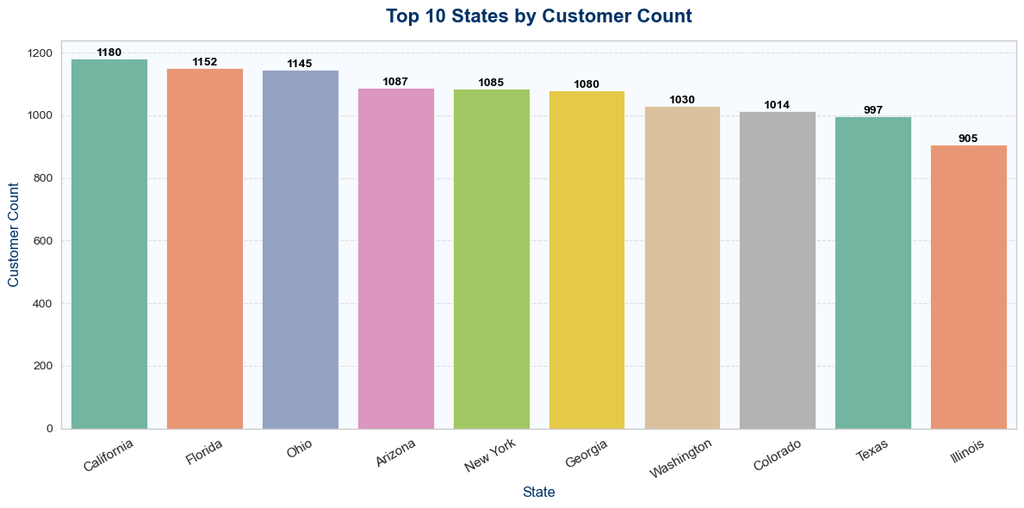

```python
# Enhanced Top 10 States Plot
# Prepare data
top_states = df['State'].value_counts().head(10)

# Set modern style
sns.set_style("whitegrid")
plt.figure(figsize=(12,6))

# Custom color palette
colors = sns.color_palette("Set2", len(top_states))

# Create barplot
ax = sns.barplot(
    x=top_states.index,
    y=top_states.values,
    palette=colors
)

# Add title and labels
plt.title("Top 10 States by Customer Count", fontsize=16, fontweight='bold', color="#003366", pad=15)
plt.xlabel("State", fontsize=12, color="#003366")
plt.ylabel("Customer Count", fontsize=12, color="#003366")

# Rotate x labels for readability
plt.xticks(rotation=30, fontsize=11)

# Add value labels on top of bars
for p in ax.patches:
    ax.annotate(
        f"{int(p.get_height())}",
        (p.get_x() + p.get_width() / 2., p.get_height()),
        ha='center', va='bottom',
        fontsize=10, color="black", fontweight="bold"
    )

# Optional background polish
plt.gca().set_facecolor("#F7FBFF")
plt.grid(axis='y', linestyle='--', alpha=0.6)

plt.tight_layout()
plt.show()
```

### Top 10 States — Customer Distribution Insight

The chart highlights the states with the highest customer representation:

- **California (1180)** → Largest customer base, a key market for targeted campaigns.
- **Florida (1152) & Ohio (1145)** → Strong presence, nearly equal to California, forming secondary hubs.
- **Arizona (1087), New York (1085), Georgia (1080)** → Mid-tier states with consistent customer counts.
- **Washington (1030) & Colorado (1014)** → Solid representation, potential for regional growth.
- **Texas (997)** → Slightly below 1000, still a significant contributor.
- **Illinois (905)** → Lowest among the top 10 but remains an important market.

**Key Observations:**

- The distribution is **fairly balanced**, with most top states contributing ~900–1200 customers.
- **California leads**, but the margin over Florida and Ohio is small, suggesting multiple strong markets rather than a single dominant one.
- The spread across diverse regions (West, South, Midwest, East) indicates **broad geographic coverage**.

**Business Insight:**

- Focus marketing and customer engagement strategies on **California, Florida, and Ohio** as primary growth drivers.
- Maintain strong regional campaigns in **Arizona, New York, and Georgia** to leverage mid-tier markets.
- Explore opportunities to **boost presence in Illinois and Texas**, where customer counts are slightly lower but still significant.

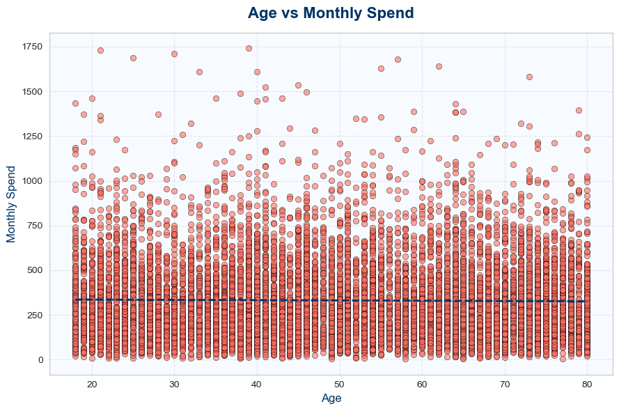

```
Correlation between Age and Monthly Spend: -0.01
```

```python
# Age vs Monthly Spend Scatter Plot
# Set modern style
sns.set_style("whitegrid")
plt.figure(figsize=(9,6))

# Create scatterplot with custom aesthetics
sns.scatterplot(
    data=df,
    x='Age',
    y='MonthlySpend',
    color="#FF6F61",   # coral red points
    alpha=0.6,
    edgecolor="black"
)

# Add regression line for trend analysis
sns.regplot(
    data=df,
    x='Age',
    y='MonthlySpend',
    scatter=False,
    color="#003366",
    line_kws={"linewidth":2, "linestyle":"--"}
)

# Title and labels
plt.title("Age vs Monthly Spend", fontsize=16, fontweight='bold', color="#003366", pad=15)
plt.xlabel("Age", fontsize=12, color="#003366")
plt.ylabel("Monthly Spend", fontsize=12, color="#003366")

# Optional background polish
plt.gca().set_facecolor("#F7FBFF")
plt.grid(alpha=0.5, linestyle="--")

plt.tight_layout()
plt.show()

# Quick correlation statistic
corr = df['Age'].corr(df['MonthlySpend'])
print(f"Correlation between Age and Monthly Spend: {corr:.2f}")
```

### Age vs Monthly Spend — Analytical Insight

The scatter plot explores the relationship between customer age and monthly spending:

- **Correlation (-0.01):** The near-zero value indicates **no meaningful relationship** between age and spending.
- **Trend Line:** The regression line is almost flat, confirming that spending patterns are **independent of age**.
- **Data Spread:** Spending values are widely distributed across all age groups, with both younger and older customers showing similar variability.
- **Outliers:** High spenders appear across different ages, suggesting that premium customers are not concentrated in any specific age bracket.

**Key Observations:**

- Age does not drive monthly spending behavior — customers of all ages exhibit similar spending ranges.
- High-value customers are scattered across age groups, meaning **age-based segmentation alone is insufficient** for targeting premium spenders.

**Business Insight:**  
Marketing strategies should focus on **behavioral and transactional attributes** (e.g., spending habits, frequency of interaction, loyalty) rather than age demographics. Premium offers can be designed for **high spenders across all age groups**, while affordability campaigns can target the broader base without age bias.

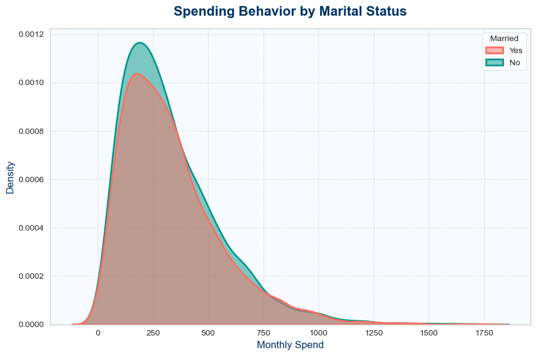

```
Average Monthly Spend (Married): 332.35
Average Monthly Spend (Not Married): 330.94
```

```python
# Spending Behavior by Marital Status
# Set modern style
sns.set_style("whitegrid")
plt.figure(figsize=(9,6))

# Custom palette for Married vs Not Married
palette = {"Yes":"#FF6F61", "No":"#009688"}  # Coral vs Teal

# KDE plot with enhancements
sns.kdeplot(
    data=df,
    x='MonthlySpend',
    hue='Married',
    fill=True,
    alpha=0.5,
    linewidth=2,
    palette=palette
)

# Title and labels
plt.title("Spending Behavior by Marital Status", fontsize=16, fontweight='bold', color="#003366", pad=15)
plt.xlabel("Monthly Spend", fontsize=12, color="#003366")
plt.ylabel("Density", fontsize=12, color="#003366")

# Optional background polish
plt.gca().set_facecolor("#F7FBFF")
plt.grid(alpha=0.5, linestyle="--")

plt.tight_layout()
plt.show()

# Quick stats summary
married_mean = df[df['Married']=="Yes"]['MonthlySpend'].mean()
not_married_mean = df[df['Married']=="No"]['MonthlySpend'].mean()

print(f"Average Monthly Spend (Married): {married_mean:.2f}")
print(f"Average Monthly Spend (Not Married): {not_married_mean:.2f}")
```

### Spending Behavior by Marital Status — Analytical Insight

The KDE plot compares monthly spending patterns between married and non-married customers:

**Key Observations:**

- Spending behavior is **consistent across marital status** groups.
- High spenders exist in both categories, suggesting premium customers are not concentrated in one group.
- Marital status is **not a strong predictor** of monthly spend.

**Business Insight:**  
Segmentation strategies should focus on **behavioral and transactional attributes** (e.g., frequency of purchases, loyalty, product categories) rather than marital status. Campaigns can be designed inclusively, ensuring both married and non-married customers are targeted with similar offers, while premium strategies should identify high spenders across both groups.

# Step 4: Bivariate Analysis

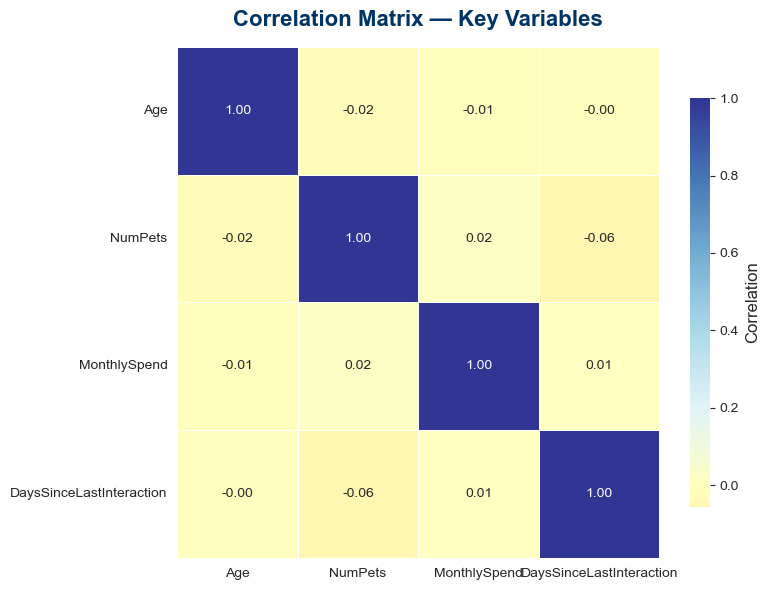

```python
# Correlation Matrix Heatmap
# Compute correlation matrix
corr = df[['Age','NumPets','MonthlySpend','DaysSinceLastInteraction']].corr()

# Set modern style
sns.set_style("white")
plt.figure(figsize=(8,6))

# Create heatmap with enhancements
ax = sns.heatmap(
    corr,
    annot=True,              # show correlation values
    fmt=".2f",               # format values to 2 decimals
    cmap="RdYlBu",           # vibrant diverging colormap
    center=0,                # center around zero
    linewidths=0.5,          # grid lines between cells
    cbar_kws={"shrink":0.8, "label":"Correlation"}
)

# Title styling
plt.title("Correlation Matrix — Key Variables", fontsize=16, fontweight='bold', color="#003366", pad=15)

# Optional polish
plt.gca().set_facecolor("#F7FBFF")
plt.tight_layout()
plt.show()
```

### Correlation Matrix — Analytical Insight

The matrix explores relationships among four key variables: Age, NumPets, Monthly Spend, and Days Since Last Interaction.

- **Age vs Monthly Spend (-0.01):** No meaningful correlation; spending is independent of age.
- **Age vs NumPets (-0.02):** Negligible relationship; pet ownership does not vary with age.
- **NumPets vs Monthly Spend (0.02):** Very weak positive correlation; owning more pets does not significantly increase spending.
- **NumPets vs Days Since Last Interaction (-0.06):** Slight negative correlation; customers with more pets may interact marginally more frequently.
- **Monthly Spend vs Days Since Last Interaction (0.01):** No significant relationship; spending is not tied to recency of interaction.

**Key Observations:**

- All correlations are **close to zero**, indicating that these variables are largely independent.
- No strong linear relationships exist, meaning predictive models should not rely on these variables alone.
- Behavioral and transactional features (e.g., frequency of purchases, product categories) may provide stronger signals than demographic attributes.

**Business Insight:**  
Since demographic factors (age, pets) and interaction recency show minimal correlation with spending, segmentation strategies should focus on **behavioral drivers**. Advanced techniques like clustering or RFM (Recency, Frequency, Monetary) analysis may yield more actionable insights than relying on simple correlations.

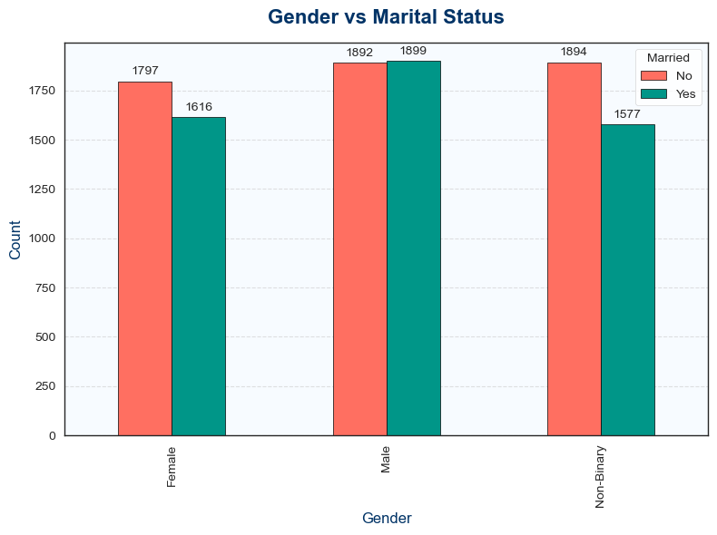

```python
# Gender vs Marital Status Plot
import matplotlib.pyplot as plt
import seaborn as sns
import pandas as pd

# Create crosstab
cross_tab = pd.crosstab(df['Gender'], df['Married'])

# Plot as grouped bar chart
plt.figure(figsize=(8,6))
cross_tab.plot(kind='bar', figsize=(8,6), color=["#FF6F61","#009688"], edgecolor="black")

# Title and labels
plt.title("Gender vs Marital Status", fontsize=16, fontweight='bold', color="#003366", pad=15)
plt.xlabel("Gender", fontsize=12, color="#003366")
plt.ylabel("Count", fontsize=12, color="#003366")

# Add value labels on bars
for container in plt.gca().containers:
    plt.bar_label(container, fmt='%d', fontsize=10, padding=3)

# Polish background
plt.gca().set_facecolor("#F7FBFF")
plt.grid(axis='y', linestyle='--', alpha=0.6)

plt.tight_layout()
plt.show()
```

### Gender vs Marital Status — Analytical Insight

The chart compares marital status distribution across gender categories:

- **Female:**
  - Not Married → 1797
  - Married → 1616  
    Slightly more females are unmarried, showing a modest gap.
- **Male:**
  - Not Married → 1892
  - Married → 1899  
    Counts are nearly equal, indicating balanced representation.
- **Non-Binary:**
  - Not Married → 1894
  - Married → 1577  
    Noticeable difference, with more individuals identifying as non-binary being unmarried.

**Key Observations:**

- **Males** show the most balanced split between married and unmarried.
- **Females and Non-Binary groups** lean toward being unmarried, though the difference is not extreme.
- Overall, marital status distribution is relatively balanced across genders, with no overwhelming skew.

**Business Insight:**  
Marital status does not drastically differ across genders, but slight variations exist.

- Campaigns targeting **family-oriented products/services** may resonate more with married males.
- **Lifestyle or independent offerings** could be positioned toward unmarried females and non-binary customers.
- Inclusive strategies should ensure messaging reflects both married and unmarried segments across all genders.

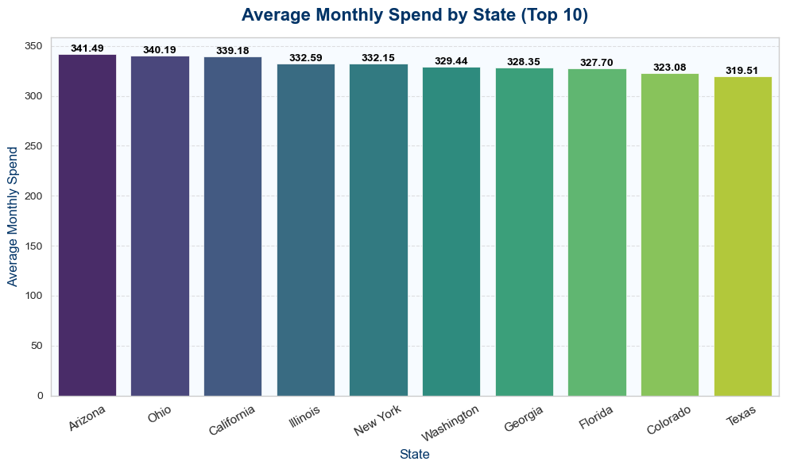

```python
# Average Monthly Spend by State
# Prepare grouped data
state_spend = df.groupby('State')['MonthlySpend'].mean().sort_values(ascending=False).head(10)

# Set modern style
sns.set_style("whitegrid")
plt.figure(figsize=(10,6))

# Create barplot
ax = sns.barplot(
    x=state_spend.index,
    y=state_spend.values,
    palette="viridis"
)

# Title and labels
plt.title("Average Monthly Spend by State (Top 10)", fontsize=16, fontweight='bold', color="#003366", pad=15)
plt.xlabel("State", fontsize=12, color="#003366")
plt.ylabel("Average Monthly Spend", fontsize=12, color="#003366")

# Rotate x labels for readability
plt.xticks(rotation=30, fontsize=11)

# Add value labels on bars
for p in ax.patches:
    ax.annotate(
        f"{p.get_height():.2f}",
        (p.get_x() + p.get_width() / 2., p.get_height()),
        ha='center', va='bottom',
        fontsize=10, color="black", fontweight="bold"
    )

# Optional background polish
plt.gca().set_facecolor("#F7FBFF")
plt.grid(axis='y', linestyle='--', alpha=0.6)

plt.tight_layout()
plt.show()
```

### Average Monthly Spend by State — Analytical Insight

The chart highlights the states with the highest average monthly spending:

- **Arizona (USD341.49)** → Highest average spend, indicating a premium market.
- **Ohio (USD340.19) & California (USD339.18)** → Close behind Arizona, strong high-value markets.
- **Illinois (USD332.59) & New York (USD332.15)** → Mid-tier but still above USD330 average spend.
- **Washington (USD329.44), Georgia (USD328.35), Florida (USD327.70)** → Consistent spending levels, slightly lower but stable.
- **Colorado (USD323.08) & Texas (USD319.51)** → Lowest among the top 10, yet still significant contributors.

**Key Observations:**

- Spending differences across states are **relatively small**, clustered between USD319–USD341.
- **Arizona leads**, but Ohio and California are nearly equal, suggesting multiple strong premium markets.
- The spread shows **broad regional spending power**, not concentrated in one state.

**Business Insight:**

- Prioritize **Arizona, Ohio, and California** for premium product launches or high-value campaigns.
- Maintain strong engagement in **Illinois and New York**, which show solid mid-tier spending.
- Explore opportunities to **boost spending in Texas and Colorado**, where averages are slightly lower but customer bases remain large.

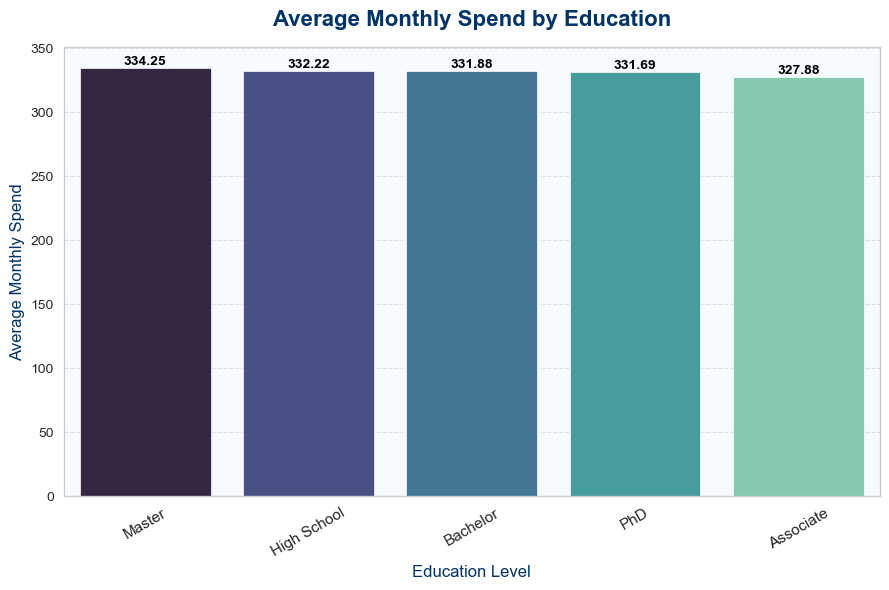

```python
# Average Monthly Spend by Education Level
# Prepare grouped data
edu_spend = df.groupby('Education')['MonthlySpend'].mean().sort_values(ascending=False)

# Set modern style
sns.set_style("whitegrid")
plt.figure(figsize=(9,6))

# Create barplot
ax = sns.barplot(
    x=edu_spend.index,
    y=edu_spend.values,
    palette="mako"
)

# Title and labels
plt.title("Average Monthly Spend by Education", fontsize=16, fontweight='bold', color="#003366", pad=15)
plt.xlabel("Education Level", fontsize=12, color="#003366")
plt.ylabel("Average Monthly Spend", fontsize=12, color="#003366")

# Rotate x labels for readability
plt.xticks(rotation=30, fontsize=11)

# Add value labels on bars
for p in ax.patches:
    ax.annotate(
        f"{p.get_height():.2f}",
        (p.get_x() + p.get_width() / 2., p.get_height()),
        ha='center', va='bottom',
        fontsize=10, color="black", fontweight="bold"
    )

# Optional background polish
plt.gca().set_facecolor("#F7FBFF")
plt.grid(axis='y', linestyle='--', alpha=0.6)

plt.tight_layout()
plt.show()
```

### Average Monthly Spend by Education — Analytical Insight

The chart compares average monthly spending across education levels:

- **Master (USD334.25)** → Highest average spend, indicating stronger purchasing power.
- **High School (USD332.22)** → Surprisingly close to Master, showing that spending is not strictly tied to higher education.
- **Bachelor (USD331.88) & PhD (USD331.69)** → Mid-range spenders, nearly identical averages.
- **Associate (USD327.88)** → Lowest average spend, though only marginally below other groups.

**Key Observations:**

- Spending differences across education levels are **minimal**, clustered between USD327–USD334.
- **Master’s degree holders** lead slightly, but the gap is not large enough to suggest strong education-based segmentation.
- The closeness of High School and advanced degrees (PhD, Master) highlights that **education level is not a major driver of spending behavior**.

**Business Insight:**  
Marketing strategies should not rely heavily on education segmentation, as spending patterns are broadly consistent. Instead:

- **Premium campaigns** can target Master’s degree holders, but also include High School customers who show comparable spending.
- **Broad-based offers** are effective across all education levels, since differences are marginal.
- Focus on **behavioral and lifestyle attributes** (e.g., product preferences, frequency of purchases) for sharper segmentation.

# Step 5 & 6: Hypothesis Testing

Decision Rule:

- p-value < 0.05 → Reject H₀
- p-value ≥ 0.05 → Fail to Reject H₀

```python
# Hypothesis 1: Gender vs Monthly Spend
male = df[df['Gender']=="Male"]['MonthlySpend']
female = df[df['Gender']=="Female"]['MonthlySpend']

t_stat, p_value = ttest_ind(male, female)

print("T Statistic:", t_stat)
print("P Value:", p_value)
```

```
T Statistic: 0.3391730320232445
P Value: 0.7344892727022859
```

### Hypothesis 1: Gender vs Monthly Spend

H₀: Male and Female customers spend the same.

H₁: Male and Female customers spend differently.

We conducted a two-sample t-test to compare **average monthly spending** between male and female customers.

- **Test Statistic (t):** 0.34
- **p-value:** 0.73

**Interpretation:**

- Since the p-value (0.73) is **greater than 0.05**, we **fail to reject the null hypothesis (H₀)**.
- This indicates that there is **no statistically significant difference** in monthly spending between male and female customers.
- In practical terms, gender does not appear to be a key driver of spending behavior in this dataset.

**Business Implication:**  
Marketing or segmentation strategies should not rely solely on gender-based assumptions for spending patterns. Instead, other factors such as **income level, age group, or customer segment** may provide stronger insights into spending differences.

```python
# Hypothesis 2: Education vs Monthly Spend
groups = [
    x["MonthlySpend"].values
    for _, x in df.groupby("Education")
]

f_stat, p_value = f_oneway(*groups)

print("F Statistic:", f_stat)
print("P Value:", p_value)
```

```
F Statistic: 0.2288066867370917
P Value: 0.922359467759936
```

### Hypothesis 2: Education vs Monthly Spend

H₀: Average spending is equal across education levels.

H₁: At least one education level has different spending.

We performed a **one-way ANOVA** to test whether average monthly spending differs across education levels.

- **F Statistic:** 0.23
- **p-value:** 0.92

**Interpretation:**

- Since the p-value (0.92) is **much greater than 0.05**, we **fail to reject the null hypothesis (H₀)**.
- This means there is **no statistically significant difference** in monthly spending across different education levels.
- In other words, education level does not appear to influence spending behavior in this dataset.

**Business Implication:**  
Customer education level is **not a strong predictor of spending patterns**. Marketing and segmentation strategies should instead focus on other variables (e.g., **income, age, or lifestyle factors**) that may provide more meaningful insights into spending behavior.

```python
# Hypothesis 3: Marital Status vs Pet Ownership
contingency_table = pd.crosstab(
    df['Married'],
    df['NumPets']
)

chi2, p_value, dof, expected = chi2_contingency(contingency_table)

print("Chi Square:", chi2)
print("P Value:", p_value)
```

```
Chi Square: 177.63953668537033
P Value: 2.3957232932397494e-37
```

### Hypothesis 3: Marital Status vs Pet Ownership

H₀: Marital status and pet ownership are independent.

H₁: Marital status and pet ownership are related.

We conducted a **Chi-Square test of independence** to examine whether marital status is related to pet ownership.

- **Chi-Square Statistic:** 177.64
- **p-value:** 2.40e-37

**Interpretation:**

- The p-value is **far below 0.05**, so we **reject the null hypothesis (H₀)**.
- This indicates a **strong, statistically significant relationship** between marital status and pet ownership.
- In other words, pet ownership patterns vary meaningfully depending on whether a customer is married or not.

**Business Implication:**  
Marital status can be a **valuable segmentation factor** for campaigns related to pet products or services. For example:

- Married customers may show different preferences in pet ownership compared to single customers.
- Tailored offers (e.g., family-oriented pet care packages vs. individual pet owner deals) could improve engagement and conversion.

```python
# Hypothesis 4: Age vs Inactivity
corr, p_value = pearsonr(
    df['Age'],
    df['DaysSinceLastInteraction']
)

print("Correlation:", corr)
print("P Value:", p_value)
```

```
Correlation: -0.003970230104955041
P Value: 0.6816905437300954
```

### Hypothesis 4: Age vs Inactivity

H₀: Age and inactivity are not related.

H₁: Age and inactivity are related.

We performed a **Pearson correlation test** to examine whether age is related to customer inactivity (measured as days since last interaction).

- **Correlation Coefficient (r):** -0.004
- **p-value:** 0.68

**Interpretation:**

- The correlation is **very close to zero**, indicating **no meaningful linear relationship** between age and inactivity.
- Since the p-value (0.68) is **greater than 0.05**, we **fail to reject the null hypothesis (H₀)**.
- This suggests that age does not significantly influence how long customers remain inactive.

**Business Implication:**  
Age is **not a reliable predictor** of customer inactivity. Retention strategies should instead focus on behavioral or transactional factors (e.g., **purchase frequency, engagement with campaigns, or loyalty program participation**) rather than demographic age groups.

```python
# Hypothesis 5: State vs Monthly Spend
state_groups = [
    x["MonthlySpend"].values
    for _, x in df.groupby("State")
]

f_stat, p_value = f_oneway(*state_groups)

print("F Statistic:", f_stat)
print("P Value:", p_value)
```

```
F Statistic: 1.117842364087718
P Value: 0.34571886479238273
```

### Hypothesis 5: State vs Monthly Spend

We performed a **one-way ANOVA** to test whether average monthly spending differs across states.

- **F Statistic:** 1.12
- **p-value:** 0.35

**Interpretation:**

- Since the p-value (0.35) is **greater than 0.05**, we **fail to reject the null hypothesis (H₀)**.
- This means there is **no statistically significant difference** in monthly spending across states.
- In other words, geographic state does not appear to influence spending behavior in this dataset.

**Business Implication:**  
State-level segmentation is **not a strong driver** of spending differences. Marketing and resource allocation strategies should instead focus on **customer demographics, lifestyle, or behavioral factors** that show stronger statistical significance.

# Step 7: Business Insights

### Customer Insights – A Statistical Investigation

### Key Findings from Hypothesis Testing

1. **Gender vs Monthly Spend**
   - No significant difference in spending between male and female customers.
   - 👉 Gender is **not a strong driver** of spending behavior.
2. **Education vs Monthly Spend**
   - No significant difference in spending across education levels.
   - 👉 Education level does **not influence spending patterns**.
3. **Marital Status vs Pet Ownership**
   - Strong, statistically significant relationship found.
   - 👉 Marital status is a **valuable segmentation factor** for pet-related products/services.
4. **Age vs Inactivity (Days Since Last Interaction)**
   - No meaningful correlation between age and inactivity.
   - 👉 Age is **not a predictor** of customer engagement or retention.
5. **State vs Monthly Spend**
   - No significant difference in spending across states.
   - 👉 Geographic state is **not a key driver** of spending behavior.

### Business Insights

- **Demographics like gender, education, age, and state do not significantly impact spending or engagement.**
- **Marital status shows strong influence on pet ownership**, making it a useful segmentation variable for targeted campaigns.
- **Behavioral and transactional factors (purchase frequency, loyalty program participation, engagement with campaigns)** are likely stronger predictors of customer value.
- Marketing strategies should **shift focus from broad demographics to behavioral segmentation** for better targeting and retention.
- For pet-related products, **marital status segmentation** can unlock differentiated offers (e.g., family-oriented vs individual pet owner campaigns).

### Strategic Takeaway

Customer behavior is **better explained by lifestyle and engagement patterns** than by traditional demographics.  
Invest in **behavioral analytics and personalized campaigns** to drive retention and revenue growth.

### Objective

Analyze customer demographics, spending behavior, engagement patterns, and demographic influences using statistical methods.

## Key Hypothesis Results

- **Gender vs Monthly Spend** → ❌ No significant difference
- **Education vs Monthly Spend** → ❌ No significant difference
- **Marital Status vs Pet Ownership** → ✅ Strong, significant relationship
- **Age vs Inactivity** → ❌ No meaningful correlation
- **State vs Monthly Spend** → ❌ No significant difference

## Business Insights

1. **Demographics (gender, education, age, state)**
   - Do **not significantly impact spending or engagement**.
   - 👉 Traditional demographic segmentation is weak.
2. **Marital Status & Pet Ownership**
   - Strong relationship detected.
   - 👉 Valuable segmentation factor for **pet-related campaigns**.
3. **Behavioral & Transactional Factors**
   - Likely stronger predictors of customer value.
   - 👉 Focus on **purchase frequency, loyalty program participation, and campaign engagement**.

## Strategic Takeaways

- Shift marketing focus from **broad demographics** to **behavioral segmentation**.
- Use **marital status** for targeted pet product/service campaigns.
- Invest in **personalized engagement strategies** to improve retention and revenue.
- Build dashboards that highlight **behavioral drivers** rather than static demographics.

### Executive Summary

Customer behavior is **better explained by lifestyle and engagement patterns** than by demographics.  
👉 To maximize ROI, prioritize **behavioral analytics, loyalty tracking, and personalized campaigns** over traditional demographic segmentation.

```python
!jupyter nbconvert --to html project_2_Nandan.ipynb
```